# Genome Wide Association Analyses (II)

# Manhattan plot (naive GWAS)

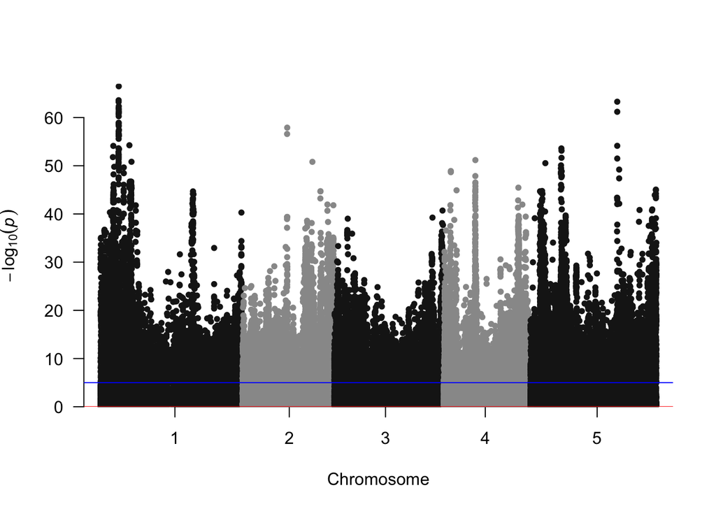

```r
 suppressMessages(library(qqman))
 DF=data.frame(SNP=colnames(GENO),CHR=MAP$chr,BP=MAP$pos,P=GWAS$pValue)
 manhattan(DF,genomewideline=0.05/ncol(GENO))
```

# QQ plot (naive GWAS)

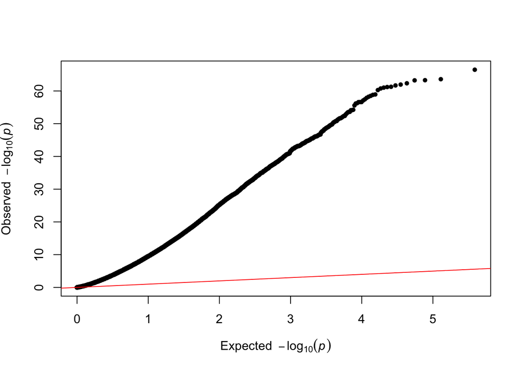

```r
 qq(DF$P)
```

# Assesment of population structure

**SNP-derived principal components**

- We will compute a genomic relationship matrix using 10,000 evenly spaced SNPs,
- Then extract the top-2 eigenvectors
- Plot the scores for the top-2 eigenvectors, coloring by genetic group.

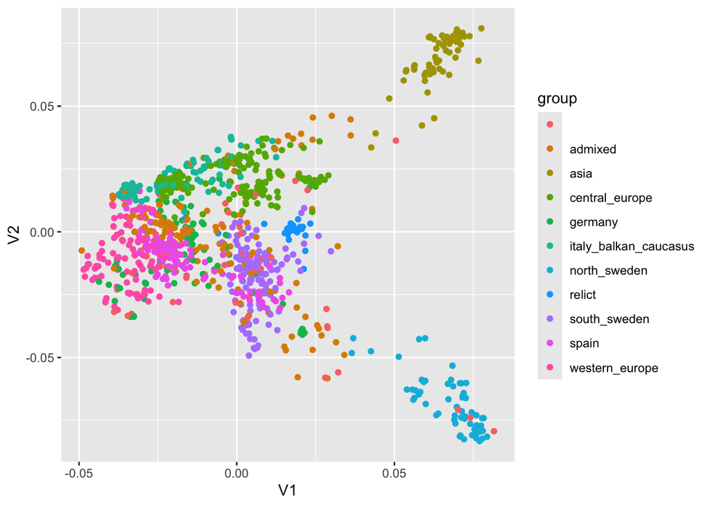

```r
 p=ncol(GENO)
 tmp=round(seq(from=10,to=p-10,length=10000))
 Z=scale(GENO[,tmp],center=TRUE,scale=FALSE)
 G=tcrossprod(Z)
 G=G/mean(diag(G))
 EVD=eigen(G)
 DF=data.frame(V1=EVD$vectors[,1],V2=EVD$vectors[,2],group=PHENO$group)
 library(ggplot2)
 p=ggplot(DF,aes(x=V1,y=V2,col=group))+geom_point()
 plot(p)
```

# GWAS accounting for population structure using 5 PCs

- Lets include the top-5 PCs in the model

```r
 Z=as.matrix(EVD$vectors[,1:5])
 H0=lm(y~Z) # baseline model

 GWAS2=data.frame(SNP=colnames(GENO),freqNA=NA,
                maf=NA,estimate=NA,SE=NA,z=NA,pValue=NA)
 GWAS2$freqNA=GWAS$freqNA
 GWAS2$maf=GWAS$maf


for(i in 1:ncol(GENO)){
  x=GENO[,i]
  Ha<-update(H0,.~.+GENO[,i]) # updating the baseline model adding 1 SNP
  GWAS2[i,4:7]= summary(Ha)$coef[7,] # extracting estimates, SE and p-values
  if(i%%1000==0) print(i)
}

 fwrite(GWAS2,file='GWAS_ARABIDOPSIS_5PCs.csv',sep=',')
```

# Manhattan plot (with 5 PCs)

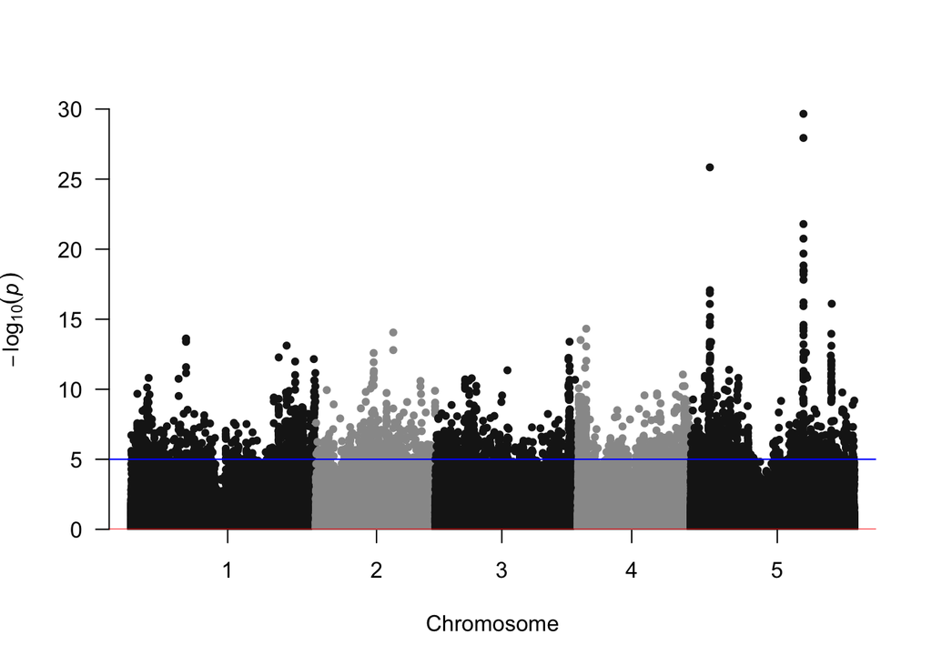

```r
 DF2=data.frame(SNP=colnames(GENO),CHR=MAP$chr,BP=MAP$pos,P=GWAS2$pValue)
 manhattan(DF2,genomewideline=0.05/ncol(GENO))
```

# QQ plot (with 5 PCs)

- The qqplot looks better but still shows evidence of p-value inflation.
- This happens because 5 PCs in this case are not enough to account for genomic relationships in this data set.

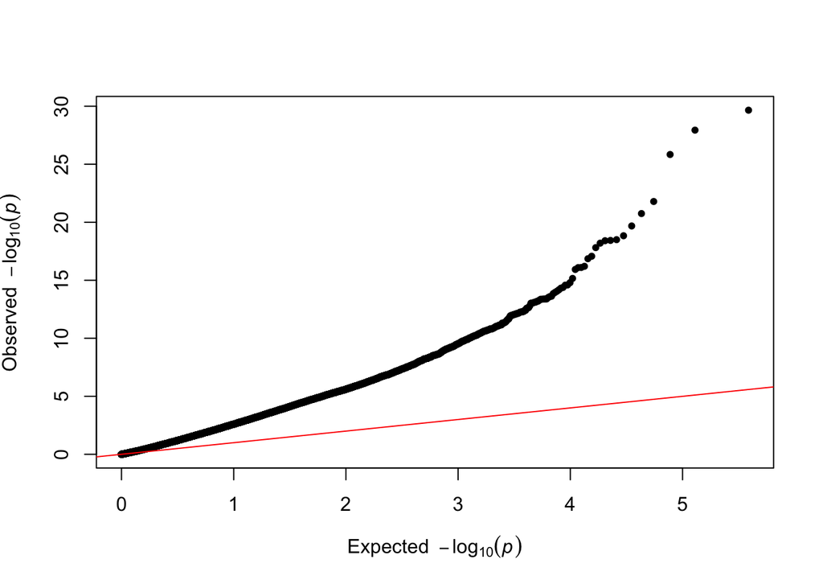

```r
 qq(DF2$P)
```

# Mixed effects models

$$y=Xβ+Zu+ε$$

- $y_{n×1}$ phenotype vector,
- $X_{n×q}$ incidence matrix for fixed effects (baseline model + 1 SNP)
- $Z_{n×r}$ links observations to genotypes (if we have one measurement per genotype, $n=r$ and $Z=I$,
- $u_{r×1}$ vector of random effects (used to model a polygenic component), $u\sim N(0,Gσ_u^2 )$,
- $ε_{n×1}$ vector of error terms, typically, $ε \sim N(0,Iσ_ε^2 )$.
- The heritability in this model is $h^2=(σ_u^2)/(σ_u^2+σ_ε^2 )$.

# Estimation (classical approach, REML+GLS)

- Estimate variance parameters ($\sigma^2_u$ and $\sigma^2_{\varepsilon}$) using REML (or ML)
- Estimate β through Maximum Likelihood, conditional on variance parameters, the estimator a Generalized Least Squares of the following form

$$\hat{\beta}=[X'V^{-1}X]^{-1}X'V^{-1}y$$

Where $V=[ZGZ'σ_u^2+Iσ_ε^2 ]$ is the phenotypic (co)variance matrix.

# GWAS using GLS (i.e., including a GRM)

### 1) Estimating variance components

```r
 # using custom code, try GENESIS as well! (see HW3)
  source('https://raw.githubusercontent.com/gdlc/STAT_GEN/refs/heads/main/HW/HW3_GWAS/h2_ML_REML.R')

  fm=fitREML(y=PHENO$FT10_mean,K=G) # can pass EVD instead of G
```

### 2) GWAS using GLS

Here I use custom code, I engourage you to try GENESIS and/or GCTA (see HW and handouts for examples)

```r
 source('https://raw.githubusercontent.com/gdlc/STAT_GEN/refs/heads/main/HW/HW3_GWAS/GWAS_OLS_GLS.R')
 Z=matrix(nrow=nrow(GENO),ncol=1,1)

 system.time(GWAS3<-SMR.GLS(y=y,X=GENO[,1:100],G=G,Z=Z,varComp=fm$estimates))
```

```
##    user  system elapsed
##   1.658   0.029   1.701
```

```r
 head(GWAS3)
```

```
##       snp    estimate       SE      pValue
## 1  1- 657  3.25592085 1.104185 0.003261367
## 2 1- 3102  2.65785608 1.039043 0.010666863
## 3 1- 4648  3.25525962 1.104652 0.003280728
## 4 1- 4880 -1.35100091 1.312162 0.303434173
## 5 1- 5975  2.34386849 1.714420 0.171869757
## 6 1- 6063  0.02529829 1.032257 0.980452249
```